# Introduction to SDMs

zoontutorials team

6 February 2017

# Why do we fit species distribution models?

In ecology, we often want to understand where species are distributed in the environment and why. Sometimes we ask these questions to gain more knowledge about a species, yet other times we simply need to know where it is to better manage it.

# What is a species distribution model?

Where we find species in geographic species is the result of three factors: the abiotic environment, the biotic environment, and the species’ movement. Together, these three factors determine the species’ ecological niche. For example, a species may be constrained by the climate required for individuals to survive, the local vegetation types it depends on, and its abillity to traverse different landscapes. The intersection of the abiotic and biotic environmental conditions constitutes the *fundamental niche*, or where the species could physiologically occur given what we know of its biology and ecology. However, experience tells us that species are not always located where we expect them to be. Their *realised niche* is where they actually exist within the bounds of the environmental space where they could potentially exist.

Species distribution models estimate a species’ realised niche. They do this by estimating the probabilty of occurrence of species along environmental gradients. They do this by estimating the correlation between environmental covariates and species occurrence data. For example, using SDMs, we can estiamte the probability a species of bird will use forest habitat with high tree cover compared to open habitat with low tree cover. We can then take these statisical relationships and project them onto geographic space, which allows us to visualise on a map how the probability of species occurrence varies in geographic space.

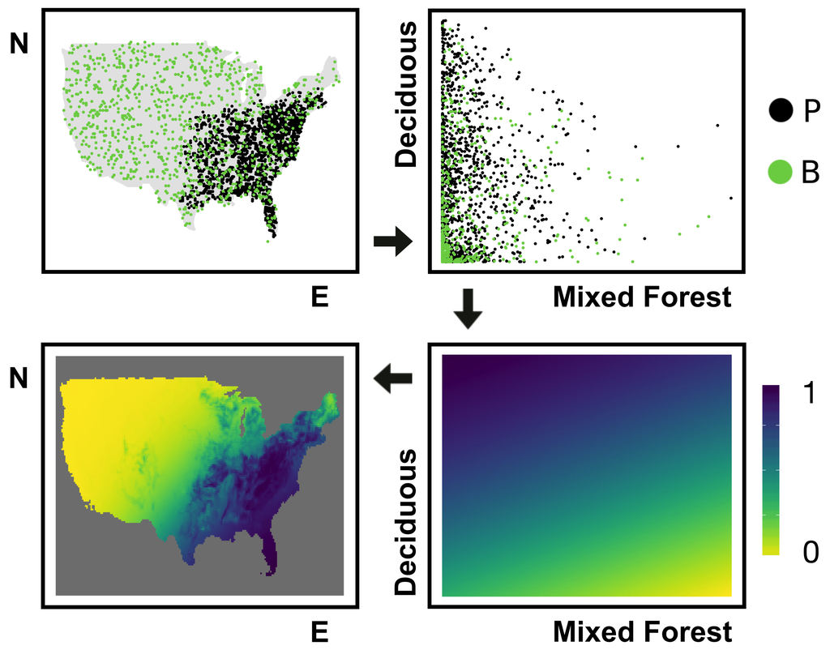

*Figure 1. Species Distribution Model Theory. Presence-background points plotted on geographic space, on environmental space, and probability of occurrence predictions plotted on environmental and geographic space.*

# How do I fit a species distribution model with `zoon`?

`zoon` is concerned with correlative SDMs, as described above, which are the most widely used SDM. This tutorial will focus on distribution models that estimate probability of occurrence, however, we could also use species abundance data to estimate how abundance varies along environemntal gradients.

1. Occurence: We first gather and format our species occurrence data.
2. Covariates: Next, we gather and format the environmental covariates we believe are important to our species of interest.
3. Process: Often our data, both occurrence and environmental, will need some pre-processing before we fit our models.
4. Model: We then fit one or more statistical models to our data to estimate species probability of occurrence.
5. Output: Finally, after fitting our model, we produce model outputs, such as graphs and maps, to enable us to make ecological inference about the species.

The `zoon` workflow is structured around these five steps and designed to make building and fitting SDMs straight-foward and reproducible. The primary zoon function is `workflow()`, which we use to fit the SDM. The workflow function has five arguments, one for each step in the SDM fitting process. For each argument, we need only to select a ‘module.’ The modules we choose in each step determine what type of model we run with what data and what outputs we produce.

This tutorial will guide you through the process of selecting a module for each argument of the `workflow()` function. Along the way, we’ll introduce some key factors that you should consider when fitting and evaluating an SDM.

But first, let’s fit a quick and simple SDM with `zoon` as a means of introduction. Don’t forget to load the package!

```r
library(zoon)
```

A basic workflow for the Joshua tree from California could look like this:

```r
zoon_workflow <- workflow(occurrence = SpOcc("Yucca brevifolia", extent = c(-119, -113, 34, 39)),
                          covariate = Bioclim(extent = c(-120, -112, 33, 40)),
                          process = Background(100),
                          model = MaxEnt,
                          output = InteractiveMap)
```

[interactive chart not shown]

Throughout this tutorial we will guide you step-by-step through each of the arguments in a workflow as we update this `zoon_workflow`. Be sure to explore the other tutorials…

`zoon` comes with several pre-existing modules for each argument, and we will go through a selection of these modules in more detail in this tutorial. You might like to explore some different combinations yourself, and you can find more information by running the `GetModuleList()` command.

# The five `zoon` workflow steps *edit*

## Step 1. Occurrence

Species distribution models are fitted with species occurrence data, the most common of which are: presence-only, presence-background, and presence-absence. Less commonly, species distribution models can be fitted with abundance data.

- Presence-only data is usually sourced from museum or herbarium records, and is a list of all recorded sightings/captures of a species with its location.
- Presence-background data is a type of presence-only data that combines presence records with randomly generated background points, also called ‘pseudo-absences’. This is the more common of the two types.
- Presence-absence data generally comes from structured field surveys where the presence *or* absence of the target species is recorded for a given site.

Presence-only data is widely and freely accesible only and as a result is more commonly used than presence-absence data. As such, we write this tutorial for presence-only data and note any necessary alterations for presence-absence data.

The first module required in a `workflow()` is `occurrence` and it is where we load our species occurrence data. There are three methods for loading data into our workflow depending on where the data is sourced: we can use pre-existing `occurrence` modules in `zoon` like `Lorem_ipsum_UK`, download data from an online repository using `SpOcc`, or load in our own data from a local computer using `LocalOccurrenceData`.

`zoon` has several functions available to view the contents of each module in the workflow. For example, we can view our species occurrence data using the `Occurrence()` accessor function (using the `head()` function to see only the first six lines):

```r
head(Occurrence(zoon_workflow))
```

```
##   longitude latitude value     type fold
## 1 -117.2910 34.41064     1 presence    1
## 2 -113.0669 34.21495     1 presence    1
## 3 -113.0728 34.23488     1 presence    1
## 4 -113.0302 34.17748     1 presence    1
## 5 -113.1449 34.33298     1 presence    1
## 6 -113.0428 34.18420     1 presence    1
```

The first two columns provide the geographic location of the observation (as longitude and latitude), the third column is the observation value (1 = presence, 0 = absence), the fourth column is the type of observation, and the last column identifies the “fold” (folds are covered later in the section of `Process` modules, but a default model can be considered to always have one fold).

## Step 2. Covariates

The second module required in a `workflow` is for environmental data. As with `occurrence` modules, there are lots of different modules to choose from. There are `zoon` modules that contain data, such as `CarolinaWrenRasters`. There are modules that source data from online sources such as `Bioclim`. And we can also load our own data from a local computer using `LocalRaster`.

Covariates use the rasterStack data format to store data and the `Covariate()` function extracts the covariates from the workflow.

```r
Covariate(zoon_workflow)
```

```
## class       : RasterBrick
## dimensions  : 42, 48, 2016, 5  (nrow, ncol, ncell, nlayers)
## resolution  : 0.1666667, 0.1666667  (x, y)
## extent      : -120, -112, 33, 40  (xmin, xmax, ymin, ymax)
## coord. ref. : +proj=longlat +datum=WGS84 +ellps=WGS84 +towgs84=0,0,0
## data source : in memory
## names       : bio1, bio2, bio3, bio4, bio5
## min values  :    2,   63,   35, 2024,  157
## max values  :  231,  193,   62, 9512,  448
```

Using what we’ve learned here, lets update `zoon_workflow` so that we can build an SDM for the Carolina Wren in the USA. CarolinaWrenPo is an occurrence module that comes pre-loaded with presence only data for the Carlonia wrne ifor north america. As presence-only data is the most commonly used data type for SDMs lets use the presence-only version of the dataset using `CarolinaWrenPO`, and we get the environmental data from `CarolinaWrenRasters`.

```r
zoon_workflow <- ChangeWorkflow(workflow = zoon_workflow,
                                occurrence = CarolinaWrenPO,
                                covariate = CarolinaWrenRasters)
```

[interactive chart not shown]

While we have used some existing data modules in this tutorial, there are modules available that will obtain occurrence and environmental data for you from online repositories such as GBIF and Bioclim. Here we show you the difference between datasets for the Carolina Wren from the pre-loaded modules `CarolinaWrenPO` and `CarolinaWrenRasters` compared with datsets sourced from online repositories using the modules `SpOcc` and `Bioclim`. We already know the extent of the datsets from the pre-loaded modules (-138.71, -52.58, 18.15, 54.95) so we will use those values for the online repositories as well.

```r
zoon_data <- workflow(occurrence = CarolinaWrenPO,
                      covariate = CarolinaWrenRasters,
                      process = Background(100),
                      model = MaxEnt,
                      output = PrintMap)
```

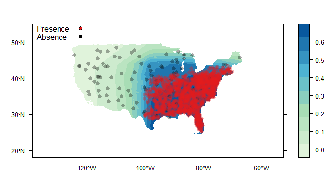

```r
online_repositories <- workflow(occurrence = SpOcc("Thryothorus ludovicianus",
                                                   extent = c(-138.71, -52.58, 18.15, 54.95)),
                                covariate = Bioclim(extent = c(-138.71, -52.58, 18.15, 54.95)),
                                process = Background(100),
                                model = MaxEnt,
                                output = PrintMap)
```

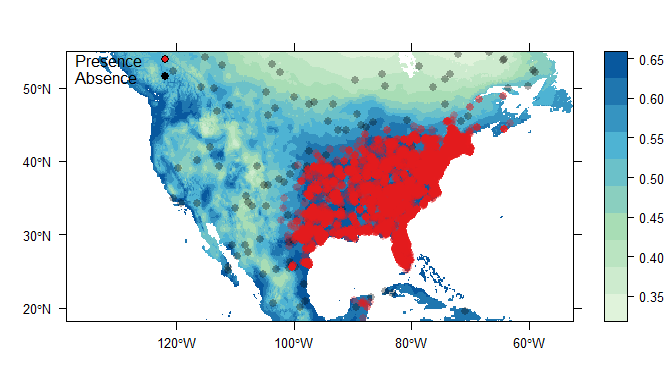

## Step 3. Process

Now that we have loaded in our species and environmental data using the `occurrence` and `covariate` modules, the `process` modules will perform any pre-processing of our data required before fitting the model itself. This is where we can modify our raw data by removing poor data points using the `Clean` module or standardising our covariates using `StandardiseCov`, generate the background data points required for presence-only data analysis using `Background`, add interaction terms between our covariates using `addInteractions`, or set up model validation methods using modules like `CrossValidate`.

Let’s check out our environmental data by using the function `Covariate()`. This function returns a summary of our raster data. In this case, we have six covariates stored in raster layers which are themselves stored in a raster brick. Our covariates are the percentage of mixed (pcMix), deciduous (pcDec), and coniferous (pcCon) forests as well as the percentage of grassland (pcGr). We have also included latitude and longitude so we can quantify the changes in the species distribution in geographic space.

```r
Covariate(zoon_workflow)   # Before standardisation
```

```
## class       : RasterBrick
## dimensions  : 165, 297, 49005, 6  (nrow, ncol, ncell, nlayers)
## resolution  : 0.29, 0.223  (x, y)
## extent      : -138.7131, -52.58307, 18.1523, 54.9473  (xmin, xmax, ymin, ymax)
## coord. ref. : +init=epsg:4326 +proj=longlat +datum=WGS84 +no_defs +ellps=WGS84 +towgs84=0,0,0
## data source : in memory
## names       :      pcMix,      pcDec,      pcCon,       pcGr,        Lat,        Lon
## min values  : -0.2816289, -0.4023483, -0.4118219, -0.4333224, -1.5588675, -1.3447938
## max values  :  10.949743,   5.785296,   5.671915,   5.118029,   1.505573,   1.255225
```

Since we are using presence-only data in our model we need to generate some background data, also known as pseudo-absences. Depending on the type of model (see next section), this data is used to either sample the range of environmental space in the landscape to compare it to where the species has been found, or as a non-presence class of data. We also want to standardise our covariates, so to use multiple modules in an argument we can use the `Chain()` function. Here we use `StandardiseCov` to standardise our covariates and `Background` to generate 1000 (increased from 100 in early examples) background points.

```r
zoon_workflow <- ChangeWorkflow(workflow = zoon_workflow,
                                process = Chain(StandardiseCov, Background(n = 1000)))
```

[interactive chart not shown]

In some instances we may not need a `process` module in your `workflow`, however, it is a mandatory argument and so the `NoProcess` module can be used as a ‘blank’ module.

## Step 4. Model

Now, let’s update our `workflow` with another common model type, logistic regression. We do this by using the aptly named `LogisticRegression` module.

```r
zoon_workflow <- ChangeWorkflow(workflow = zoon_workflow,
                                model = LogisticRegression)
```

[interactive chart not shown]

## Step 5. Output

Once we’re happy with our included data and the model type we’ve chose. And we’ve included all relevant processes, it is finally time to check our results.

Let’s start by mapping our probability of occurrence predictions onto geographic space. We can use the `InteractiveMap` module to create a map showing the predicted species distribution and over-lying presence points.

```r
zoon_workflow <- ChangeWorkflow(workflow = zoon_workflow,
                                output = InteractiveMap)
```

[interactive chart not shown]

The `InteractiveMap` module produces a map of occurrence probability that we can interact with. The map shows a scale from light green to purple and overlays our raw data on top of the map so we can see how our data align with model predictions. We can click on our raw data to get information about it.

The `InteractiveMap` shows us, accoridng to the data we included, the Carolina wren is most likely to occur in the southeast of the country (higher probability of occurrence; purple) and is less likely to exist in the northwest of the country (lower probability of occurrence; yellow). These quantitative predictions fit with a qualitative analysis of our data; most of our presence records (white dots) are in the southeast of the map.

Now we’ve seen how Carolina wren occurrence varies over geographic space, let’s look more closely at what is driving that variation. That is, how does probability of occurrence vary along the environmental gradients we included in our model. For this, we can use the `ResponsePlot` module to make graphs of the predicted relationships between probabilty of occurrence and our environmental covariate.

Without input arguments, `ResponsePlot` plots a graph for each covariate included in our model. We can also specify, which covariate we want to plot.

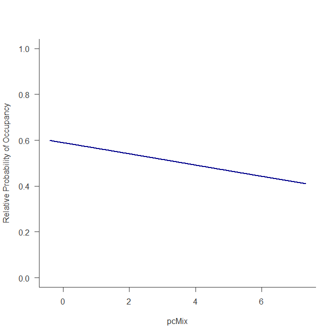

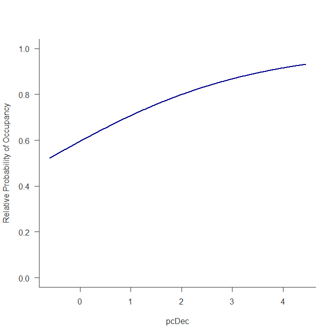

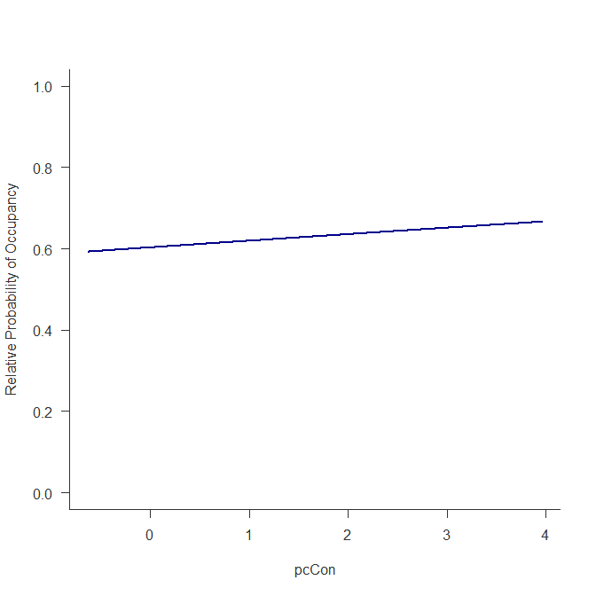

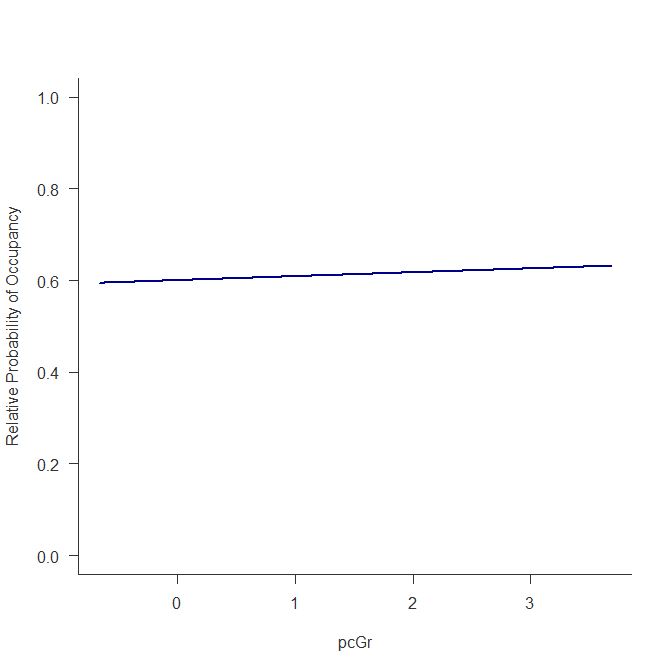

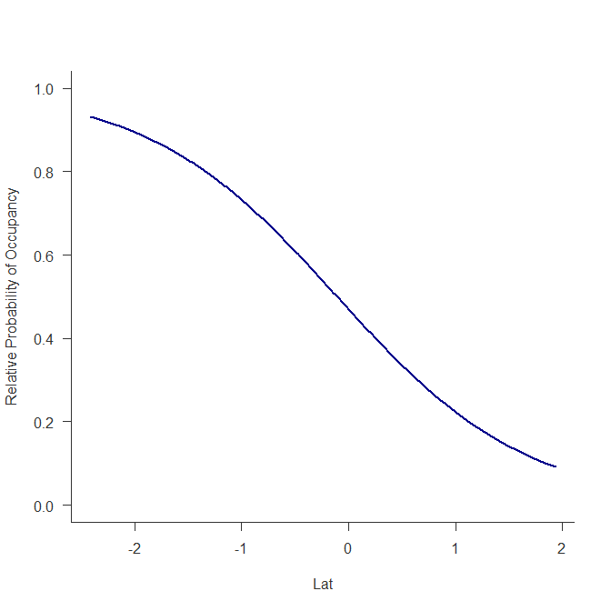

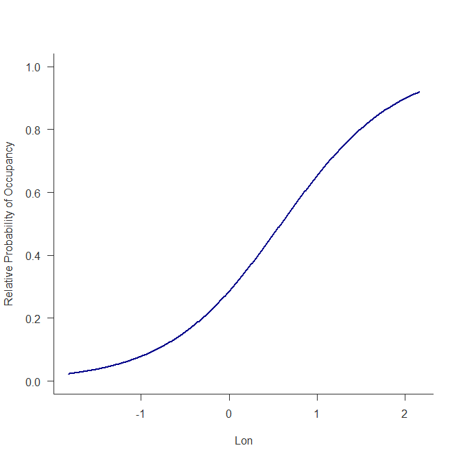

```r
zoon_workflow <- ChangeWorkflow(zoon_workflow,
                                output = ResponsePlot())
```

# Putting it all together

Now that we have seen how to use each argument in the `workflow()` function it is time to put all of the pieces together and fit our own SDM within `zoon`. As MaxEnt is arguably one of the most popular SDM methodologies, lets fit a MaxEnt model in addition to the LogisticRegression module. This is achieved using the `List()` function. We will fit these models to the Carolina Wren presence-background data set, generate 1000 background samples, and display our results in a map without our datapoints displayed. We have covered each of the necesssary modules previously, and here we will run them together to form a complete `workflow()`.

```r
Dual_Model_Workflow <- workflow(occurrence = CarolinaWrenPO,
                                covariate = CarolinaWrenRasters,
                                process = Background(1000),
                                model = list(LogisticRegression, MaxEnt),
                                output = PrintMap(points = FALSE))
```

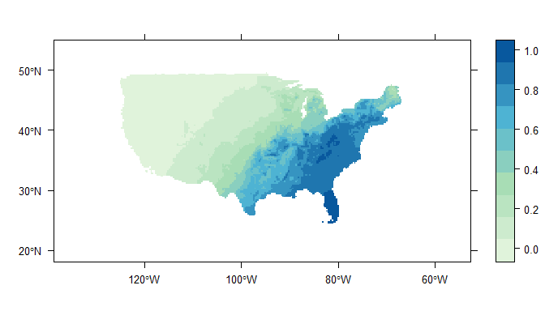

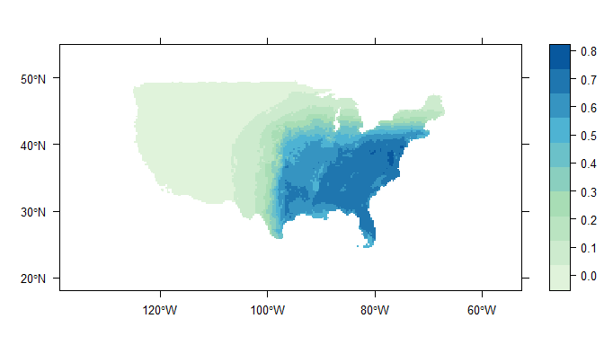

There are some obvious differences in the predicted distribution maps of these two models. There are no differences between the inputs or outputs for each model because we used a single workflow. That means each model used the same data, but the predicted distribution of the species is different between the models. What causes the difference? Check out our more detailed guide on SDM algorithm selection here “Choosing A Model” vignette

# Conclusion